# Fletcher and Fortin, Chapter 4: Spatial Dispersion and Point Data

Walkthrough by Michael France Nelson

# 1 Data import and visualization (FF 4.3.3)

*Opuntia humifusa*

In the book, the cactus boundaries filename is *cactus_boundary.csv*, however the file provided with the book’s supplemental materials is *cactus_boundaries.csv*.

The supplemental data files do not contain *cactus_boundary.csv*.

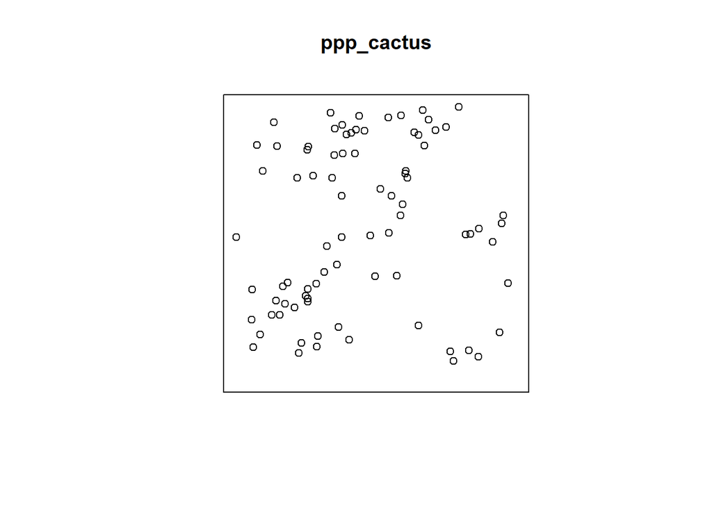

```r
cactus = read.csv(paste0(book_data, "/cactus.csv"), header = T)

# this fails
# boundary = read.csv(paste0(book_data, "/cactus_boundary.csv"), header = T)
boundary = read.csv(paste0(book_data, "/cactus_boundaries.csv"), header = T)

ppp_window = owin(xrange = c(boundary$Xmin, boundary$Xmax), yrange = c(boundary$Ymin, boundary$Ymax))
ppp_cactus = ppp(cactus$East, cactus$North, window = ppp_window)


plot(ppp_cactus)
```

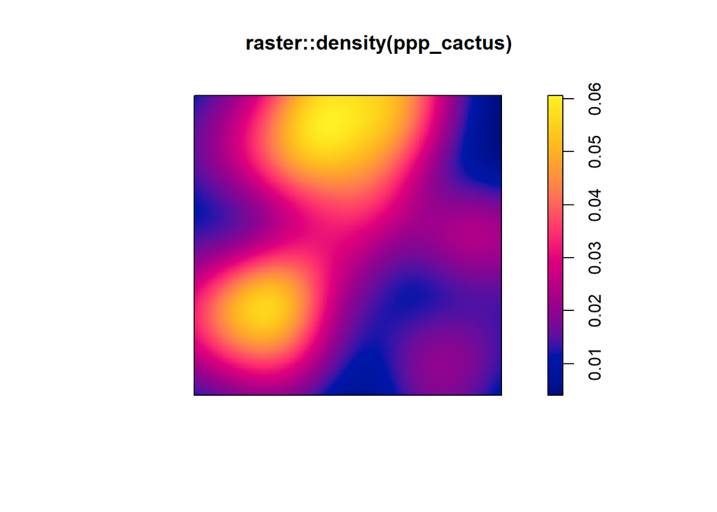

```r
plot(raster::density(ppp_cactus))
```

```r
summary(ppp_cactus)
```

```
## Planar point pattern:  82 points
## Average intensity 0.0262668 points per square unit
##
## Coordinates are given to 1 decimal place
## i.e. rounded to the nearest multiple of 0.1 units
##
## Window: rectangle = [403368, 403424.6] x [3285673, 3285728] units
##                     (56.57 x 55.18 units)
## Window area = 3121.81 square units
```

```r
# no such file
boundary_poly = readOGR(paste0(book_data, "/cactus_boundaries"))
```

```
## Error in ogrListLayers(dsn = dsn): Cannot open data source
```

## 1.1 Cactus positions vs. CSR?

Use quadrat functions in spatstat:

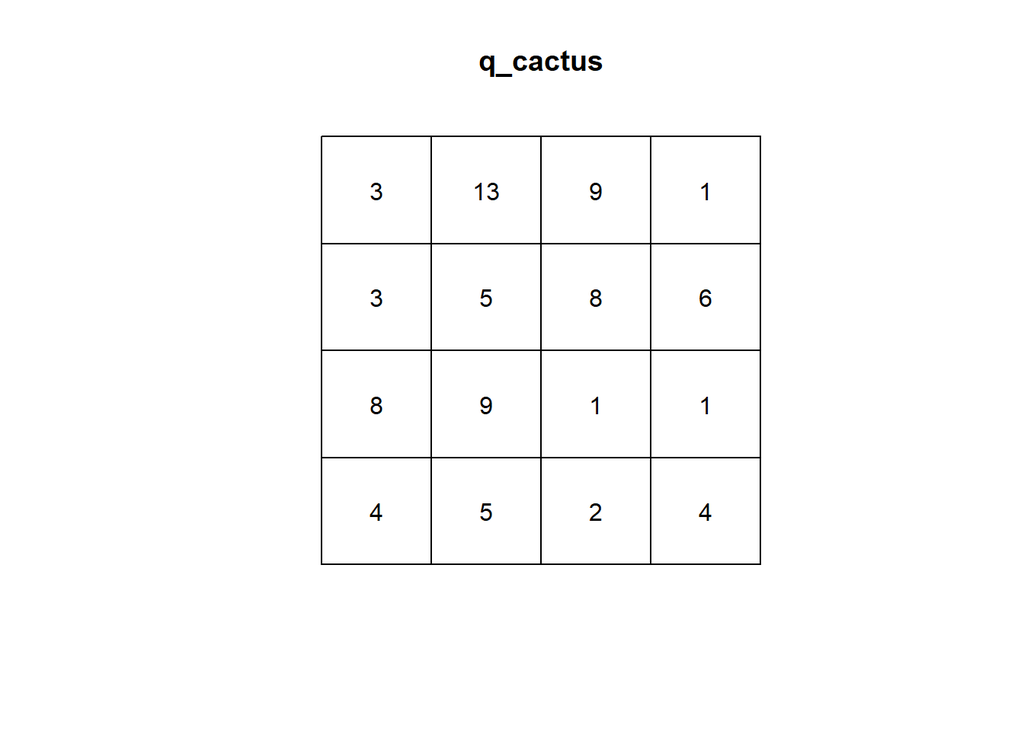

```r
q_cactus = quadratcount(ppp_cactus, nx = 4, ny = 4)
plot(q_cactus)
```

```r
str(q_cactus, 1)
```

```
##  'quadratcount' int [1:4, 1:4] 3 3 8 4 13 5 9 5 9 8 ...
##  - attr(*, "dimnames")=List of 2
##  - attr(*, "xbreaks")= num [1:5] 403368 403382 403396 403410 403425
##  - attr(*, "ybreaks")= num [1:5] 3285673 3285687 3285700 3285714 3285728
##  - attr(*, "tess")=List of 5
##   ..- attr(*, "class")= chr [1:2] "tess" "list"
```

```r
quadrat.test(ppp_cactus, nx = 4, ny = 4)
```

```
##
##  Chi-squared test of CSR using quadrat counts
##
## data:  ppp_cactus
## X2 = 35.463, df = 15, p-value = 0.004223
## alternative hypothesis: two.sided
##
## Quadrats: 4 by 4 grid of tiles
```

```r
c(q_cactus)
```

```
##  [1]  3  3  8  4 13  5  9  5  9  8  1  2  1  6  1  4
```

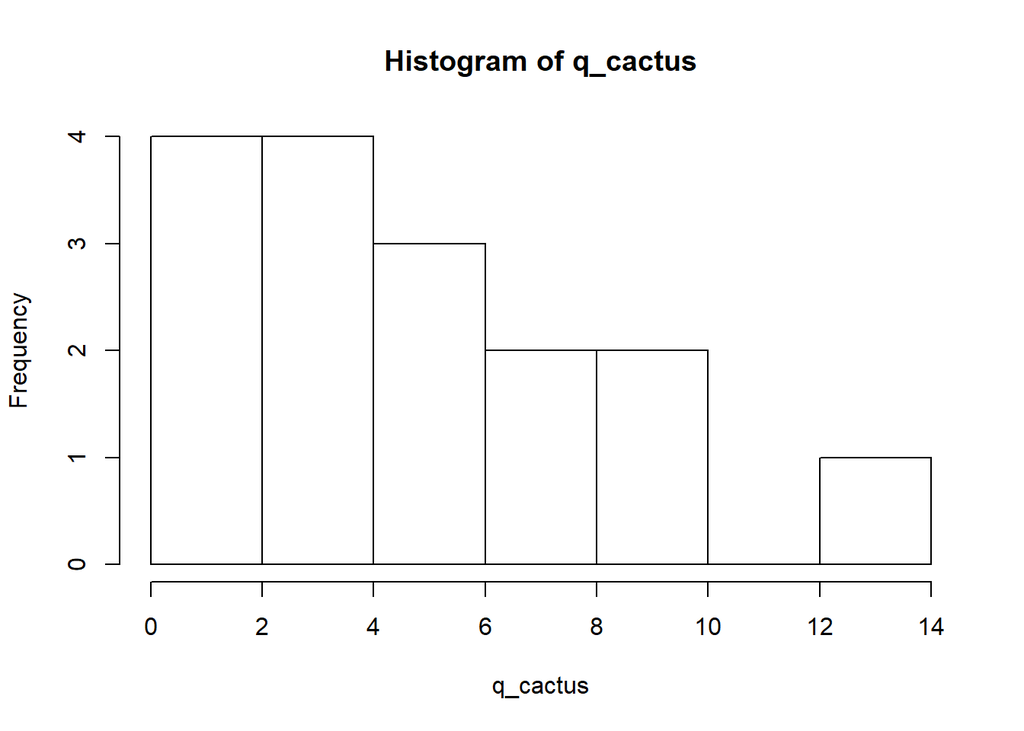

```r
hist(q_cactus)
```

# 2 Univariate Point Patterns (FF 4.3.4)

## 2.1 K and L functions

No edge effect correction.

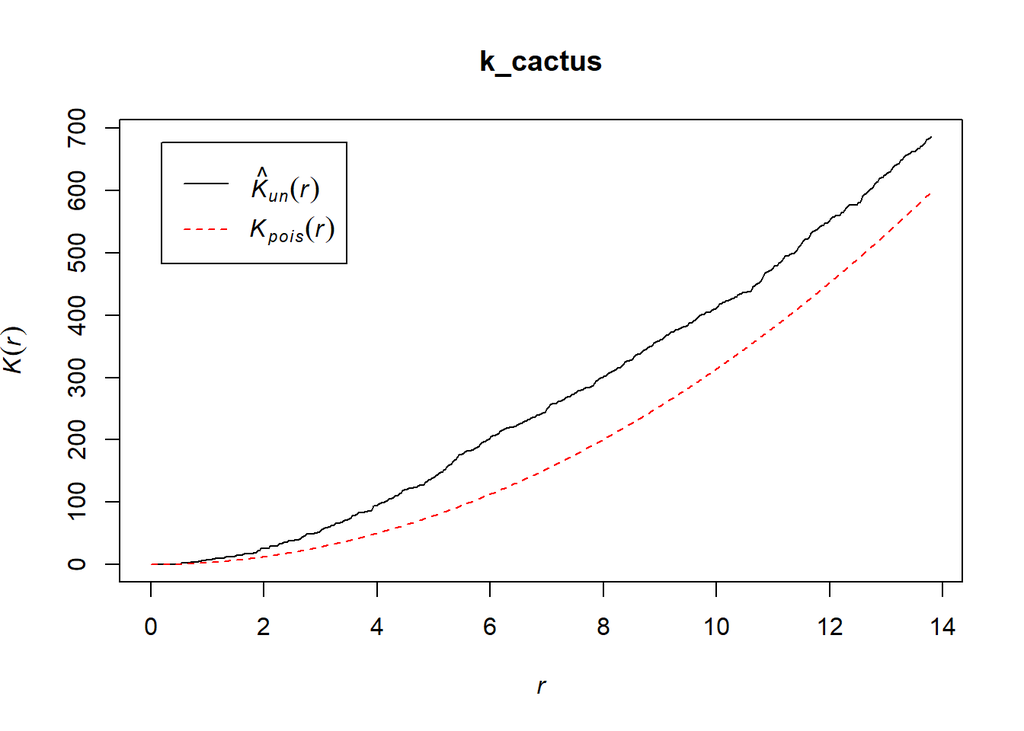

```r
k_cactus = Kest(ppp_cactus, correction = "none")
l_cactus = Lest(ppp_cactus, correction = "none")


plot(k_cactus)
```

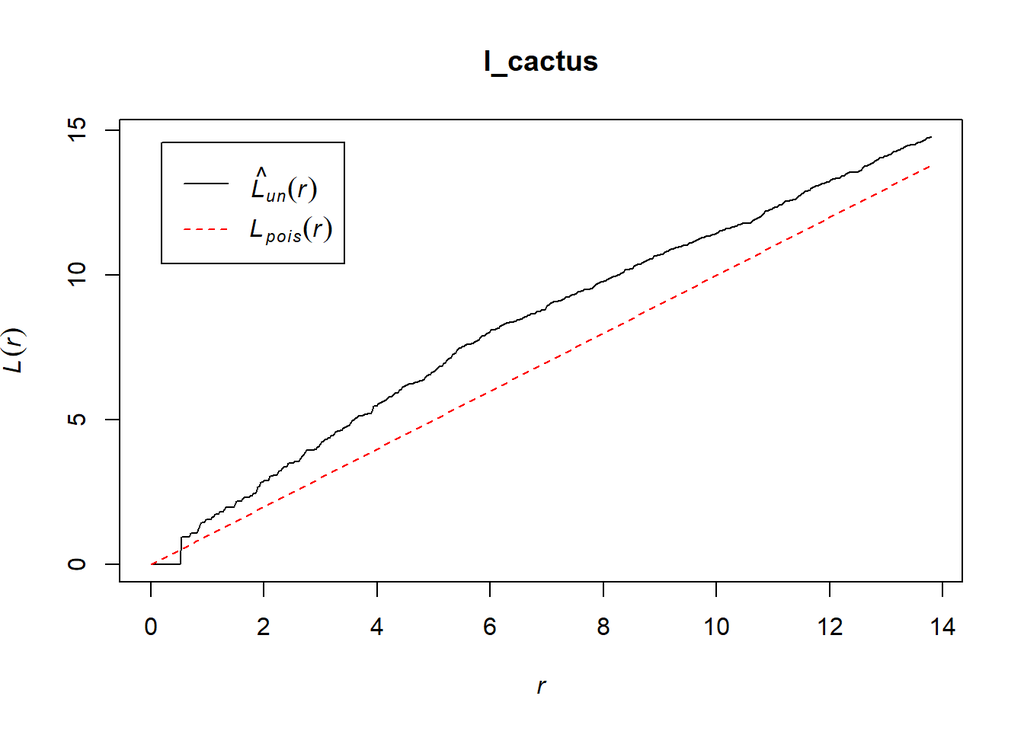

```r
plot(l_cactus)
```

```r
# k_cactus
```

## 2.2 K and L with edge correction

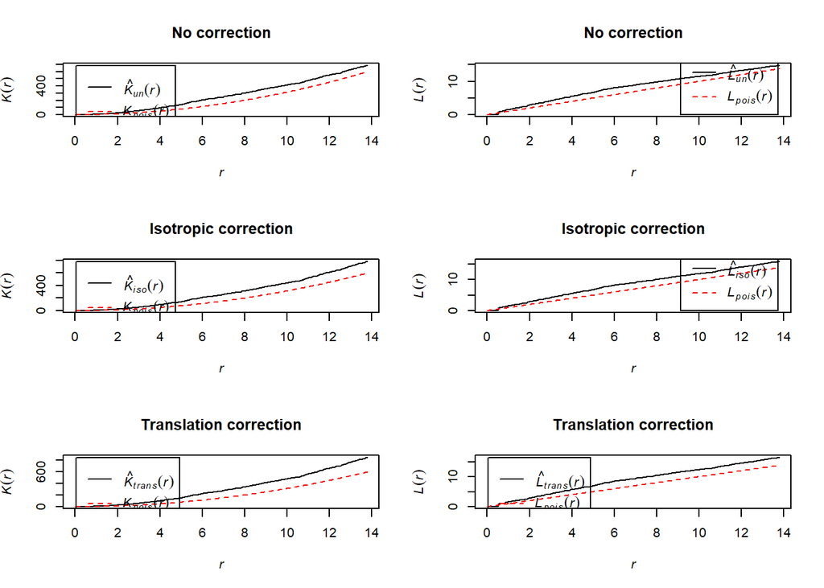

```r
k_cactus_i = Kest(ppp_cactus, correction = "isotropic")
l_cactus_i = Lest(ppp_cactus, correction = "isotropic")
k_cactus_t = Kest(ppp_cactus, correction = "translate")
l_cactus_t = Lest(ppp_cactus, correction = "translate")

{
  par(mfrow = c(3, 2))

  plot(k_cactus, main = "No correction")
  plot(l_cactus, main = "No correction")
  plot(k_cactus_i, main = "Isotropic correction")
  plot(l_cactus_i, main = "Isotropic correction")
  plot(k_cactus_t, main = "Translation correction")
  plot(l_cactus_t, main = "Translation correction")
}
```

## 2.3 L-Functions normalized to 0

I haven’t used the syntax in the second argument before but it’s kind of elegant, if a bit opaque at first.

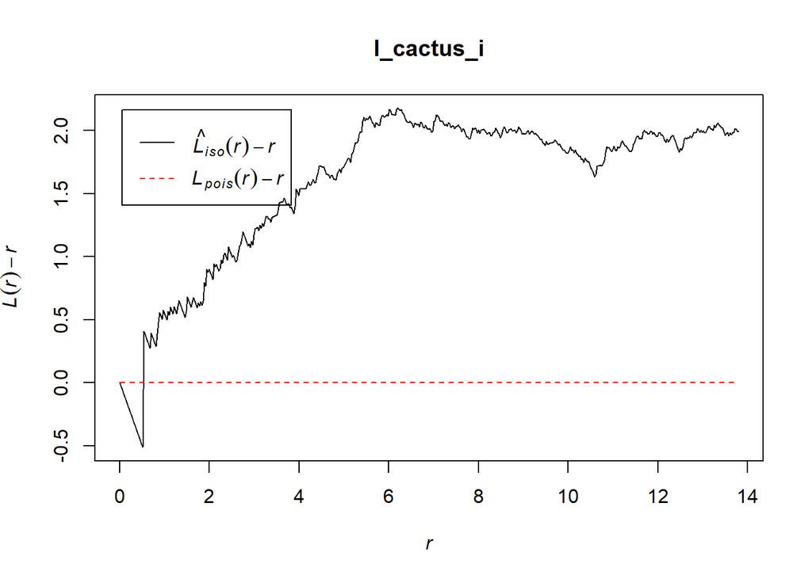

```r
plot(l_cactus_i, . - r ~ r)
```

## 2.4 Ggplot with Kest and Lest?

```r
str(l_cactus_i, 1)
```

```
## Classes 'fv' and 'data.frame':   513 obs. of  3 variables:
##  $ r   : num  0 0.0269 0.0539 0.0808 0.1078 ...
##  $ theo: num  0 0.0269 0.0539 0.0808 0.1078 ...
##  $ iso : num  0 0 0 0 0 0 0 0 0 0 ...
##  - attr(*, "argu")= chr "r"
##  - attr(*, "valu")= chr "iso"
##  - attr(*, "ylab")= language L(r)
##  - attr(*, "yexp")= language L(r)
##  - attr(*, "fmla")= chr ".~r"
##  - attr(*, "alim")= num  0 13.8
##  - attr(*, "labl")= chr  "r" "%s[pois](r)" "hat(%s)[iso](r)"
##  - attr(*, "desc")= chr  "distance argument r" "theoretical Poisson %s" "isotropic-corrected estimate of %s"
##  - attr(*, "units")=List of 3
##   ..- attr(*, "class")= chr "unitname"
##  - attr(*, "fname")= chr "L"
##  - attr(*, "dotnames")= chr  "iso" "theo"
```

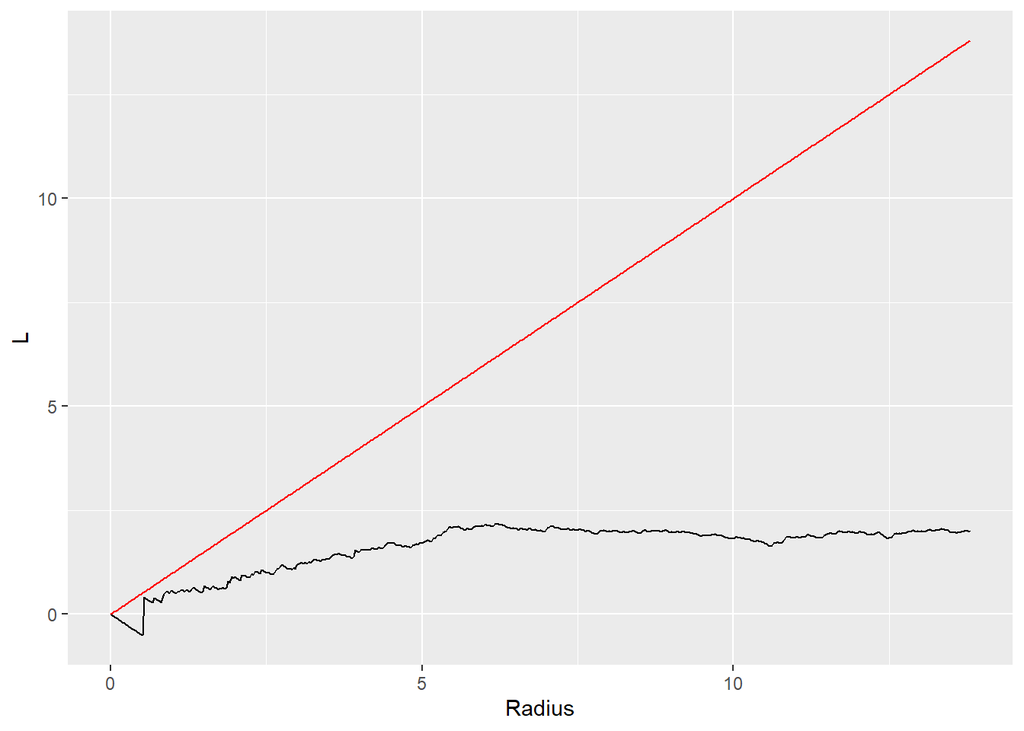

```r
ggplot(l_cactus_i, aes(x = r, y = iso - r)) +
  geom_line() +
  geom_line(aes(x = r, y = theo), colour = "red") +
  xlab("Radius") + ylab("L")
```

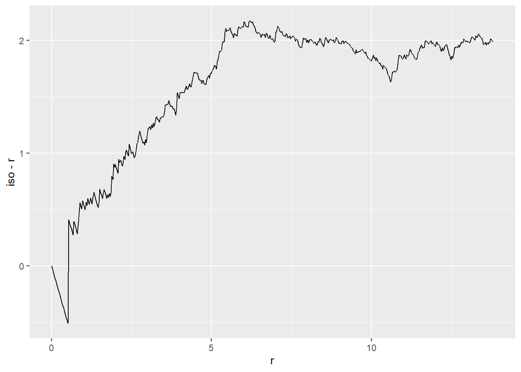

```r
ggplot(l_cactus_i, aes(x = r, y = iso - r)) +
  geom_line()
```

## 2.5 Dispersion significance

Page 118

MCMC simulation for CSR rejection region.

Figure 4.7a includes a global envelope

```r
csr_env_cactus = envelope(
  ppp_cactus,
  fun = Lest,
  nsim = 99,
  rank = 1,
  correction = "iso",
  global = FALSE)
```

```
## Generating 99 simulations of CSR  ...
## 1, 2, 3, 4, 5, 6, 7, 8, 9, 10, 11, 12, 13, 14, 15, 16, 17, 18, 19, 20, 21, 22, 23, 24, 25, 26, 27, 28, 29, 30, 31, 32, 33, 34, 35, 36, 37, 38, 39, 40,
## 41, 42, 43, 44, 45, 46, 47, 48, 49, 50, 51, 52, 53, 54, 55, 56, 57, 58, 59, 60, 61, 62, 63, 64, 65, 66, 67, 68, 69, 70, 71, 72, 73, 74, 75, 76, 77, 78, 79, 80,
## 81, 82, 83, 84, 85, 86, 87, 88, 89, 90, 91, 92, 93, 94, 95, 96, 97, 98,  99.
##
## Done.
```

```r
csr_env_cactus_global = envelope(
  ppp_cactus,
  fun = Lest,
  nsim = 99,
  rank = 1,
  correction = "isotropic",
  global = TRUE)
```

```
## Generating 99 simulations of CSR  ...
## 1, 2, 3, 4, 5, 6, 7, 8, 9, 10, 11, 12, 13, 14, 15, 16, 17, 18, 19, 20, 21, 22, 23, 24, 25, 26, 27, 28, 29, 30, 31, 32, 33, 34, 35, 36, 37, 38, 39, 40,
## 41, 42, 43, 44, 45, 46, 47, 48, 49, 50, 51, 52, 53, 54, 55, 56, 57, 58, 59, 60, 61, 62, 63, 64, 65, 66, 67, 68, 69, 70, 71, 72, 73, 74, 75, 76, 77, 78, 79, 80,
## 81, 82, 83, 84, 85, 86, 87, 88, 89, 90, 91, 92, 93, 94, 95, 96, 97, 98,  99.
##
## Done.
```

```r
str(csr_env_cactus_global, 1)
```

```
## Classes 'envelope', 'fv' and 'data.frame':   513 obs. of  5 variables:
##  $ r   : num  0 0.0269 0.0539 0.0808 0.1078 ...
##  $ obs : num  0 0 0 0 0 0 0 0 0 0 ...
##  $ theo: num  0 0.0269 0.0539 0.0808 0.1078 ...
##  $ lo  : num  -1.4 -1.37 -1.35 -1.32 -1.29 ...
##  $ hi  : num  1.4 1.43 1.45 1.48 1.51 ...
##  - attr(*, "argu")= chr "r"
##  - attr(*, "valu")= chr "obs"
##  - attr(*, "ylab")= language L(r)
##  - attr(*, "yexp")= language L(r)
##  - attr(*, "fmla")= chr ". ~ r"
##  - attr(*, "alim")= num  0 13.8
##  - attr(*, "labl")= chr  "r" "hat(%s)[obs](r)" "%s[theo](r)" "hat(%s)[lo](r)" ...
##  - attr(*, "desc")= chr  "distance argument r" "observed value of %s for data pattern" "theoretical value of %s for CSR" "lower critical boundary for %s" ...
##  - attr(*, "units")=List of 3
##   ..- attr(*, "class")= chr "unitname"
##  - attr(*, "fname")= chr "L"
##  - attr(*, "dotnames")= chr  "obs" "theo" "hi" "lo"
##  - attr(*, "shade")= chr  "lo" "hi"
##  - attr(*, "einfo")=List of 24
```

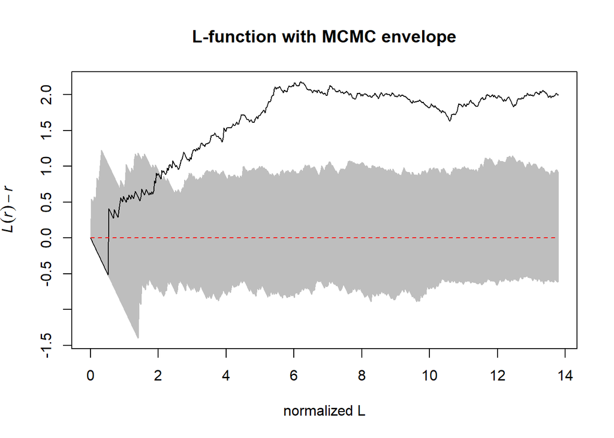

```r
# {
  # par(mfrow = c(2, 1))
  plot(csr_env_cactus, . - r ~ r, shade = c("hi", "lo"), legend = F, xlab = "normalized L", main = "L-function with MCMC envelope")
```

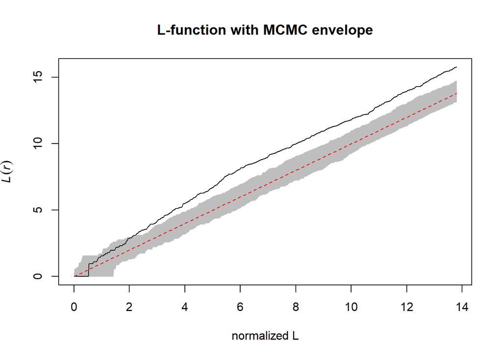

```r
  plot(csr_env_cactus, shade = c("hi", "lo"), legend = F, xlab = "normalized L", main = "L-function with MCMC envelope")
```

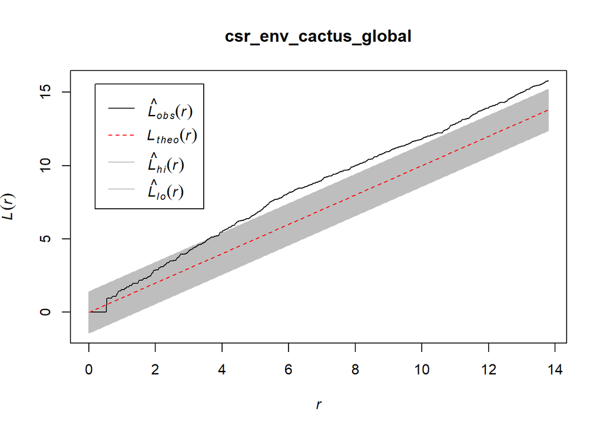

```r
  plot(csr_env_cactus_global, shade = c("hi", "lo"))
```

```r
  # plot(csr_env_cactus_none, . - r ~ r, shade = c("hi", "lo"))
# }
```

## 2.6 Pair correlation function

From page 119

Are the `translate` and `translation` options different?

From the `Kest` help entry it seems that they are…

Figure 4.7b has an additional curve with higher smoothing using a `stoyan` value higher than 0.15.

```r
pair_cactus_t = pcf(ppp_cactus, correction = "translate")
pair_cactus_t = pcf(ppp_cactus, correction = "translation")
pair_cactus_env = envelope(ppp_cactus, pcf, nsim = 99, rank = 1, correction = "translation", global = FALSE)
```

```
## Generating 99 simulations of CSR  ...
## 1, 2, 3, 4, 5, 6, 7, 8, 9, 10, 11, 12, 13, 14, 15, 16, 17, 18, 19, 20, 21, 22, 23, 24, 25, 26, 27, 28, 29, 30, 31, 32, 33, 34, 35, 36, 37, 38, 39, 40,
## 41, 42, 43, 44, 45, 46, 47, 48, 49, 50, 51, 52, 53, 54, 55, 56, 57, 58, 59, 60, 61, 62, 63, 64, 65, 66, 67, 68, 69, 70, 71, 72, 73, 74, 75, 76, 77, 78, 79, 80,
## 81, 82, 83, 84, 85, 86, 87, 88, 89, 90, 91, 92, 93, 94, 95, 96, 97, 98,  99.
##
## Done.
```

```r
pair_cactus_env_2 = envelope(ppp_cactus, pcf, nsim = 99, rank = 1, correction = "translation", global = FALSE, funargs = list(stoyan = 0.4))
```

```
## Generating 99 simulations of CSR  ...
## 1, 2, 3, 4, 5, 6, 7, 8, 9, 10, 11, 12, 13, 14, 15, 16, 17, 18, 19, 20, 21, 22, 23, 24, 25, 26, 27, 28, 29, 30, 31, 32, 33, 34, 35, 36, 37, 38, 39, 40,
## 41, 42, 43, 44, 45, 46, 47, 48, 49, 50, 51, 52, 53, 54, 55, 56, 57, 58, 59, 60, 61, 62, 63, 64, 65, 66, 67, 68, 69, 70, 71, 72, 73, 74, 75, 76, 77, 78, 79, 80,
## 81, 82, 83, 84, 85, 86, 87, 88, 89, 90, 91, 92, 93, 94, 95, 96, 97, 98,  99.
##
## Done.
```

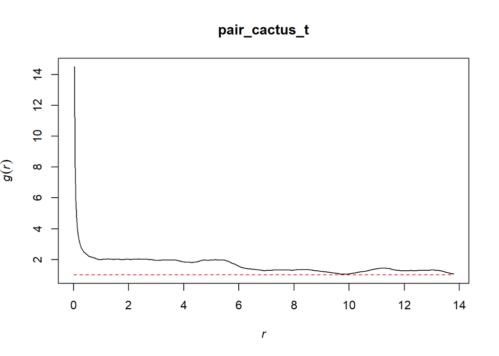

```r
plot(pair_cactus_t, legend = F)
```

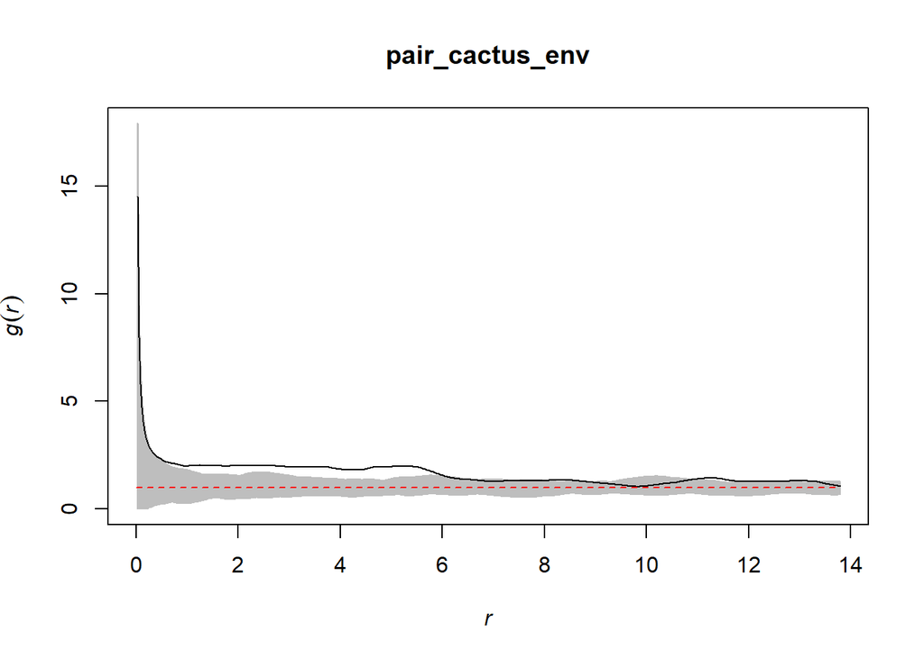

```r
plot(pair_cactus_env, legend = F)
```

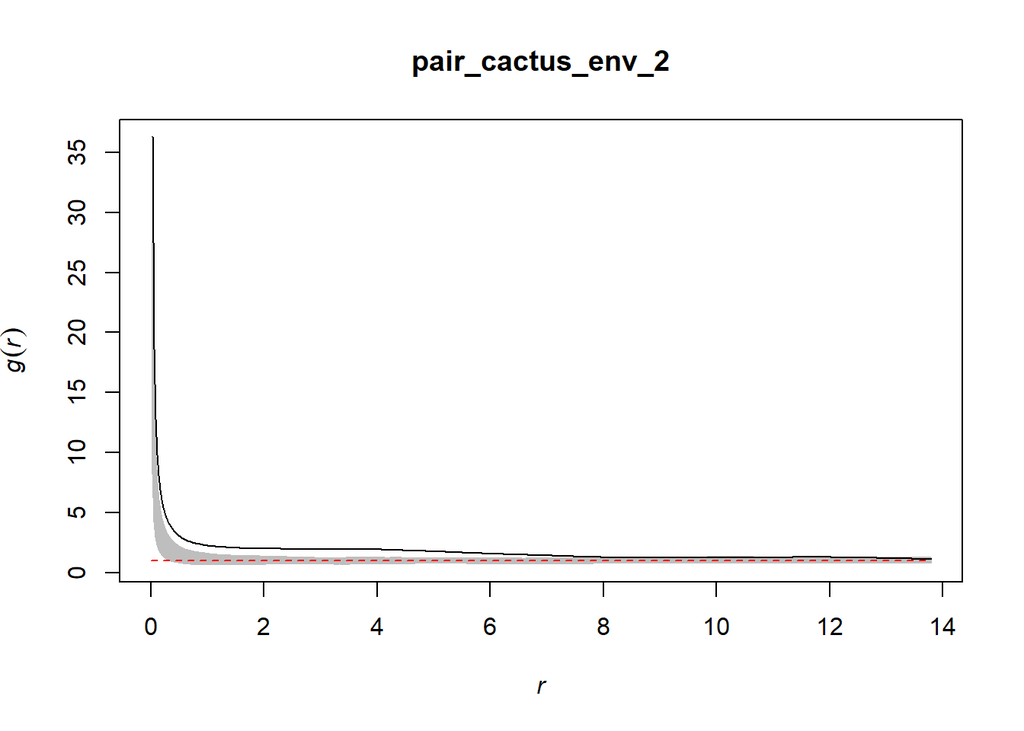

```r
plot(pair_cactus_env_2, legend = F)
```

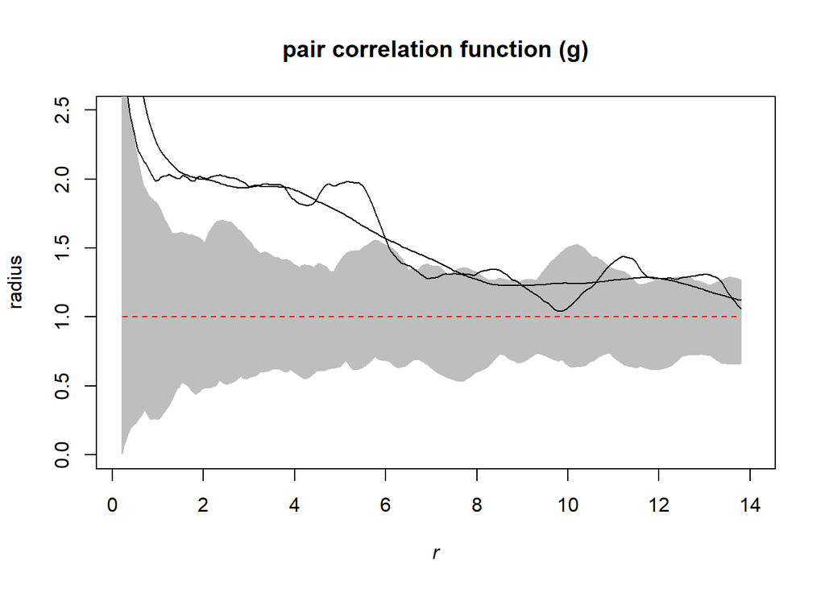

```r
{
plot(pair_cactus_env, xlim = c(0.2, 14), ylim = c(0, 2.5), legend = F, shade = c("lo", "hi"), ylab = "radius", main = "pair correlation function (g)")
points(obs ~ r, data = pair_cactus_env_2, type = "l")
}
```

## 2.7 Nearest neighbor: G-function

Y-axis is the probability that the nearest-neighbor is at most r units away. I.e. that the nearest-neighbor is closer than r units.

G(r) is higher than the 95% confidence envelope in the range of 2 to 3 meters.

High values for G(r) mean that more points have shorter nearest-neighbor distances than expected. The probability of points being closer together than r is higher than in CSR suggesting aggregation.

Adding the ECDF doesn’t add additional info and makes the plot harder to interpret (in my opinion).

```r
g_env_cactus = pair_cactus_env = envelope(ppp_cactus, Gest, nsim = 99, rank = 1, correction = "rs", global = FALSE)
```

```
## Generating 99 simulations of CSR  ...
## 1, 2, 3, 4, 5, 6, 7, 8, 9, 10, 11, 12, 13, 14, 15, 16, 17, 18, 19, 20, 21, 22, 23, 24, 25, 26, 27, 28, 29, 30, 31, 32, 33, 34, 35, 36, 37, 38, 39, 40,
## 41, 42, 43, 44, 45, 46, 47, 48, 49, 50, 51, 52, 53, 54, 55, 56, 57, 58, 59, 60, 61, 62, 63, 64, 65, 66, 67, 68, 69, 70, 71, 72, 73, 74, 75, 76, 77, 78, 79, 80,
## 81, 82, 83, 84, 85, 86, 87, 88, 89, 90, 91, 92, 93, 94, 95, 96, 97, 98,  99.
##
## Done.
```

```r
nn_cactus = nndist(ppp_cactus)
nn_cactus
```

```
##  [1]  4.4260783  2.6635887  1.9371394  1.9371394  1.9936241  1.9936241
##  [7]  3.0075319  3.0075319  7.6590747  1.8649614  3.7212714  1.8649614
## [13]  2.1298343  2.1298343  6.0314385  8.2042312  1.4947926  4.4206337
## [19]  2.0833939  2.0833939  2.0989159  3.7212714  0.9624074  0.9624074
## [25]  2.0989159  2.2224545  2.4136466  2.4136466  2.6230231  0.8872570
## [31]  1.4838720  3.0710430  4.8936800  1.4838720  0.5245074  2.9826676
## [37]  2.9826676  1.5952091  3.7523379  3.5615622  3.2366155  2.7179524
## [43]  2.6182676  1.8507752  1.2883031  0.6783988  0.5325082  4.0520357
## [49]  4.0520357  3.5429914  1.8682775  0.8552923  0.8552923  3.4228224
## [55]  3.2366155  0.5325082  1.8767165  1.4771493  1.4771493  1.7377298
## [61]  1.7377298  1.1206199  4.9555760 10.1433027  0.5245074  0.8872570
## [67]  3.4228224  2.0810247  2.0810247  2.3980819  2.3980819  3.2207448
## [73]  0.8301542  0.5180357  2.3360054  1.5952091  1.0606649  1.6288293
## [79]  1.4947926  1.1206199  0.5180357  2.6635887
```

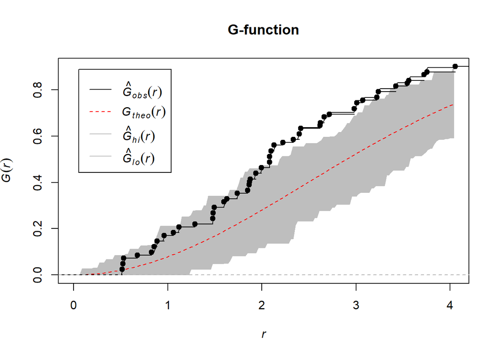

```r
plot(g_env_cactus, main = "G-function"); plot(ecdf(nn_cactus), add = T)
```

# 3 Marked Point Patterns - section 4.3.5